# $\color{brown}{\text{Time series stock price forecasting}}$

### $\color{purple}{\text{Problem Statement }}$:

To predict the future stock prices of company based on historical stock data. The objective here is to build a model that accurately forecasts the next day's closing price or predicts the overall trend in stock prices.

```python
!pip install statsmodels
```

```python
from matplotlib import dates
import matplotlib.pyplot as plt
import numpy as np
import pandas as pd
import yfinance as yf
import seaborn as sb
```

```python
import warnings
warnings.filterwarnings('ignore')
```

### $\color{purple}{\text{Data Collection}}$

NVIDIA is a well-known multinational technology company specializing in designing graphics processing units (GPUs) and artificial intelligence (AI) technologies and has exhibited a reasonable level of volatility and liquidity in its stock prices. NVIDIA could be a good choice for time series stock forecasting project as it exhibit significant volality, liquidity in market and products and innovations are widely used in gaming, machine learning, scientific computing, and autonomous vehicles, among other areas and moreover data is avialable at various financial sites. For data streaming Yahoo finance is used.

```python
df = yf.download('NVDA',start='2018-01-01',end='2023-07-10')
df
```

```
[*********************100%***********************]  1 of 1 completed
```

| Date | Open | High | Low | Close | Adj Close | Volume |
| --- | --- | --- | --- | --- | --- | --- |
| 2018-01-02 | 48.945000 | 49.875000 | 48.625000 | 49.837502 | 49.321186 | 35561600 |
| 2018-01-03 | 51.025002 | 53.424999 | 50.937500 | 53.117500 | 52.567204 | 91470400 |
| 2018-01-04 | 53.939999 | 54.512501 | 53.172501 | 53.397499 | 52.844307 | 58326800 |
| 2018-01-05 | 53.547501 | 54.227501 | 52.770000 | 53.849998 | 53.292114 | 58012400 |
| 2018-01-08 | 55.099998 | 56.250000 | 54.645000 | 55.500000 | 54.925022 | 88121600 |
| ... | ... | ... | ... | ... | ... | ... |
| 2023-06-30 | 416.799988 | 425.500000 | 415.010010 | 423.019989 | 423.019989 | 50053400 |
| 2023-07-03 | 425.170013 | 428.980011 | 422.019989 | 424.130005 | 424.130005 | 19820900 |
| 2023-07-05 | 421.350006 | 431.769989 | 420.850006 | 423.170013 | 423.170013 | 32361800 |
| 2023-07-06 | 418.440002 | 421.790009 | 413.459991 | 421.029999 | 421.029999 | 30358200 |
| 2023-07-07 | 423.220001 | 432.140015 | 421.799988 | 425.029999 | 425.029999 | 35525300 |

1387 rows × 6 columns

```python
data = df.resample('D').ffill()
data
```

| Date | Open | High | Low | Close | Adj Close | Volume |
| --- | --- | --- | --- | --- | --- | --- |
| 2018-01-02 | 48.945000 | 49.875000 | 48.625000 | 49.837502 | 49.321186 | 35561600 |
| 2018-01-03 | 51.025002 | 53.424999 | 50.937500 | 53.117500 | 52.567204 | 91470400 |
| 2018-01-04 | 53.939999 | 54.512501 | 53.172501 | 53.397499 | 52.844307 | 58326800 |
| 2018-01-05 | 53.547501 | 54.227501 | 52.770000 | 53.849998 | 53.292114 | 58012400 |
| 2018-01-06 | 53.547501 | 54.227501 | 52.770000 | 53.849998 | 53.292114 | 58012400 |
| ... | ... | ... | ... | ... | ... | ... |
| 2023-07-03 | 425.170013 | 428.980011 | 422.019989 | 424.130005 | 424.130005 | 19820900 |
| 2023-07-04 | 425.170013 | 428.980011 | 422.019989 | 424.130005 | 424.130005 | 19820900 |
| 2023-07-05 | 421.350006 | 431.769989 | 420.850006 | 423.170013 | 423.170013 | 32361800 |
| 2023-07-06 | 418.440002 | 421.790009 | 413.459991 | 421.029999 | 421.029999 | 30358200 |
| 2023-07-07 | 423.220001 | 432.140015 | 421.799988 | 425.029999 | 425.029999 | 35525300 |

2013 rows × 6 columns

```python
data.info()
```

```
<class 'pandas.core.frame.DataFrame'>
DatetimeIndex: 2013 entries, 2018-01-02 to 2023-07-07
Freq: D
Data columns (total 6 columns):
 #   Column     Non-Null Count  Dtype
---  ------     --------------  -----
 0   Open       2013 non-null   float64
 1   High       2013 non-null   float64
 2   Low        2013 non-null   float64
 3   Close      2013 non-null   float64
 4   Adj Close  2013 non-null   float64
 5   Volume     2013 non-null   int64
dtypes: float64(5), int64(1)
memory usage: 110.1 KB
```

```python
data.describe().round(2)
```

|  | Open | High | Low | Close | Adj Close | Volume |
| --- | --- | --- | --- | --- | --- | --- |
| count | 2013.00 | 2013.00 | 2013.00 | 2013.00 | 2013.00 | 2.013000e+03 |
| mean | 131.31 | 133.80 | 128.74 | 131.35 | 131.08 | 4.829378e+07 |
| std | 87.69 | 89.42 | 85.92 | 87.68 | 87.74 | 2.313295e+07 |
| min | 31.62 | 32.49 | 31.11 | 31.77 | 31.53 | 9.788400e+06 |
| 25% | 58.08 | 59.46 | 57.03 | 58.25 | 57.78 | 3.258840e+07 |
| 50% | 125.07 | 127.36 | 121.56 | 125.16 | 125.04 | 4.396240e+07 |
| 75% | 184.72 | 189.68 | 181.00 | 186.39 | 186.11 | 5.910200e+07 |
| max | 435.01 | 439.90 | 426.74 | 438.08 | 438.08 | 2.511528e+08 |

```python
data.columns
```

```
Index(['Open', 'High', 'Low', 'Close', 'Adj Close', 'Volume'], dtype='object')
```

### $\color{purple}{\text{Data Preprocessing}}$:

Clean and preprocess the collected data to make it suitable for analysis and modeling.

```python
data.isna().sum()
```

```
Open         0
High         0
Low          0
Close        0
Adj Close    0
Volume       0
dtype: int64
```

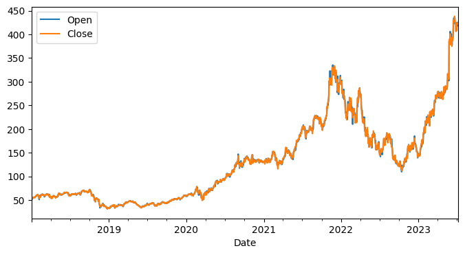

```python
(data
 [['Open', 'Close']]
 .plot(figsize = (8,4)))
```

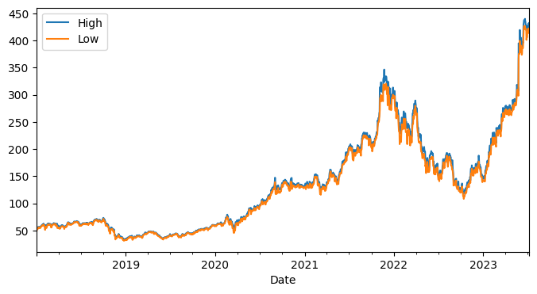

```python
(data
 [['High', 'Low']]
 #.pipe(fix_col)
 .plot(figsize = (8,4)))
```

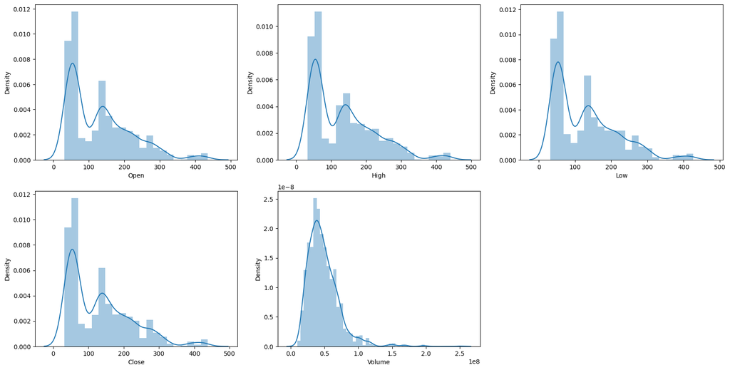

```python
features = ['Open', 'High', 'Low', 'Close', 'Volume']

plt.subplots(figsize=(20,10))

for i, col in enumerate(features):
  plt.subplot(2,3,i+1)
  sb.distplot(data[col])
plt.show()
```

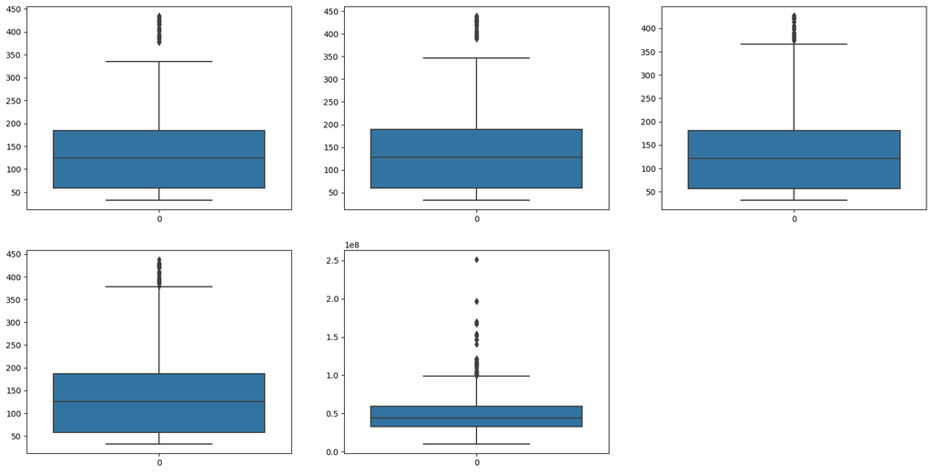

```python
features = ['Open', 'High', 'Low', 'Close', 'Volume']
plt.subplots(figsize=(20,10))
for i, col in enumerate(features):
  plt.subplot(2,3,i+1)
  sb.boxplot(data[col])
plt.show()
```

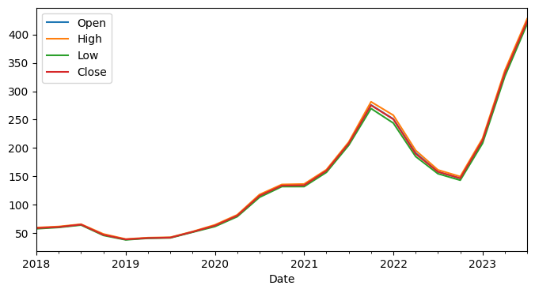

```python
#Resampling : taking data from one granulatiy to other granuality like from daily to weekly monthly of quarterly
(data
 [['Open', 'High', 'Low', 'Close']]
.resample('Q')
.mean()
.plot(figsize = (8,4))
)
```

[output not shown]

89 rows × 4 columns

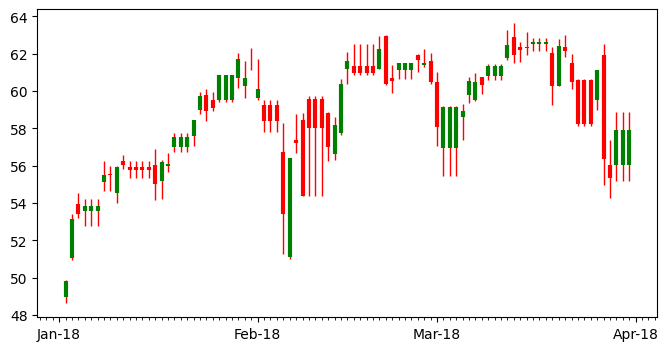

```python
#Candle stick plot
fig,ax = plt.subplots(figsize=(8,4))
def candlestick(df,ax):
    ax.vlines(x=df.index, ymin=df.Low, ymax=df.High, color='r', linewidth=1)
    red = df.query('Open > Close')
    ax.vlines(x=red.index,ymin=red.Close, ymax=red.Open, color='r', linewidth=3)
    green = df.query('Open <= Close')
    ax.vlines(x=green.index,ymin=green.Open, ymax=green.Close, color='g', linewidth=3)
    ax.xaxis.set_major_locator(dates.MonthLocator())
    ax.xaxis.set_major_formatter(dates.DateFormatter('%b-%y'))
    ax.xaxis.set_minor_locator(dates.DayLocator())
    return df
(data
#.iloc[:,::2]
#.pipe(fix_col)
.resample('d')
.agg({'Close':'last', 'Open':'first',  'High':'max', 'Low':'min'})
.loc['jan 2018':'March 2018']
.pipe(candlestick,ax)
)
```

```python
data['year'] = data.index.year
data
```

| Date | Open | High | Low | Close | Adj Close | Volume | year |
| --- | --- | --- | --- | --- | --- | --- | --- |
| 2018-01-02 | 48.945000 | 49.875000 | 48.625000 | 49.837502 | 49.321186 | 35561600 | 2018 |
| 2018-01-03 | 51.025002 | 53.424999 | 50.937500 | 53.117500 | 52.567204 | 91470400 | 2018 |
| 2018-01-04 | 53.939999 | 54.512501 | 53.172501 | 53.397499 | 52.844307 | 58326800 | 2018 |
| 2018-01-05 | 53.547501 | 54.227501 | 52.770000 | 53.849998 | 53.292114 | 58012400 | 2018 |
| 2018-01-06 | 53.547501 | 54.227501 | 52.770000 | 53.849998 | 53.292114 | 58012400 | 2018 |
| ... | ... | ... | ... | ... | ... | ... | ... |
| 2023-07-03 | 425.170013 | 428.980011 | 422.019989 | 424.130005 | 424.130005 | 19820900 | 2023 |
| 2023-07-04 | 425.170013 | 428.980011 | 422.019989 | 424.130005 | 424.130005 | 19820900 | 2023 |
| 2023-07-05 | 421.350006 | 431.769989 | 420.850006 | 423.170013 | 423.170013 | 32361800 | 2023 |
| 2023-07-06 | 418.440002 | 421.790009 | 413.459991 | 421.029999 | 421.029999 | 30358200 | 2023 |
| 2023-07-07 | 423.220001 | 432.140015 | 421.799988 | 425.029999 | 425.029999 | 35525300 | 2023 |

2013 rows × 7 columns

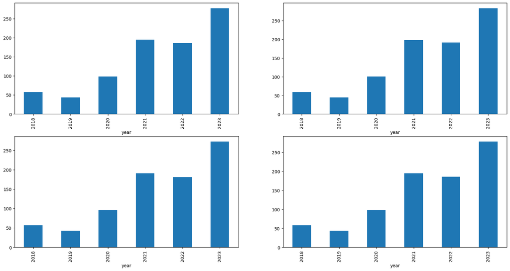

```python
data_grouped = data.groupby('year').mean()
plt.subplots(figsize=(20,10))

for i, col in enumerate(['Open', 'High', 'Low', 'Close']):
  plt.subplot(2,2,i+1)
  data_grouped[col].plot.bar()
plt.show()
```

Quarter end : A quarter is defined as company portforlio in a span of three months. Every company prepares its quarterly results and publishes them publicly so, that people can analyze the company’s performance. These quarterly results affect the stock prices heavily and can be a helpful feature for the learning model.

```python
data["is_quarter_end"]  = np.where(data.index.month % 3 ==0,1,0)
data
```

| Date | Open | High | Low | Close | Adj Close | Volume | year | is_quarter_end |
| --- | --- | --- | --- | --- | --- | --- | --- | --- |
| 2018-01-02 | 48.945000 | 49.875000 | 48.625000 | 49.837502 | 49.321186 | 35561600 | 2018 | 0 |
| 2018-01-03 | 51.025002 | 53.424999 | 50.937500 | 53.117500 | 52.567204 | 91470400 | 2018 | 0 |
| 2018-01-04 | 53.939999 | 54.512501 | 53.172501 | 53.397499 | 52.844307 | 58326800 | 2018 | 0 |
| 2018-01-05 | 53.547501 | 54.227501 | 52.770000 | 53.849998 | 53.292114 | 58012400 | 2018 | 0 |
| 2018-01-06 | 53.547501 | 54.227501 | 52.770000 | 53.849998 | 53.292114 | 58012400 | 2018 | 0 |
| ... | ... | ... | ... | ... | ... | ... | ... | ... |
| 2023-07-03 | 425.170013 | 428.980011 | 422.019989 | 424.130005 | 424.130005 | 19820900 | 2023 | 0 |
| 2023-07-04 | 425.170013 | 428.980011 | 422.019989 | 424.130005 | 424.130005 | 19820900 | 2023 | 0 |
| 2023-07-05 | 421.350006 | 431.769989 | 420.850006 | 423.170013 | 423.170013 | 32361800 | 2023 | 0 |
| 2023-07-06 | 418.440002 | 421.790009 | 413.459991 | 421.029999 | 421.029999 | 30358200 | 2023 | 0 |
| 2023-07-07 | 423.220001 | 432.140015 | 421.799988 | 425.029999 | 425.029999 | 35525300 | 2023 | 0 |

2013 rows × 8 columns

```python
data.groupby('is_quarter_end').mean()
```

| is_quarter_end | Open | High | Low | Close | Adj Close | Volume | year |
| --- | --- | --- | --- | --- | --- | --- | --- |
| 0 | 128.244329 | 130.769430 | 125.767423 | 128.384322 | 128.099778 | 4.832798e+07 | 2020.285395 |
| 1 | 137.441285 | 139.855131 | 134.683487 | 137.287329 | 137.029431 | 4.822539e+07 | 2020.272727 |

Prices are higher in the months which are quarter end as compared to that of the non-quarter end months. The volume of trades is lower in the months which are quarter end.

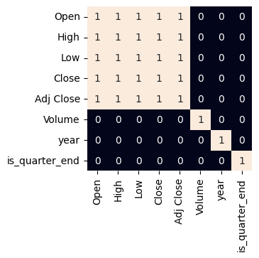

```python
plt.figure(figsize=(3, 3))

# As our concern is with the highly
# correlated features only so, we will visualize
# our heatmap as per that criteria only.
sb.heatmap(data.corr() > 0.9, annot=True, cbar=False)
plt.show()
```

# Time Series Model

The choice of the best model for time series analysis of stocks depends on various factors, including the characteristics of the data, the specific problem we are trying to incorporate, and the trade-offs that we are willing to make between model complexity and interpretability.

A time series consists of three systematic components: level, trend, and seasonality, along with a non-systematic component known as noise.

The definitions of these components are as follows:

Level: The average value observed in the series. Trend: The upward or downward movement observed in the series over time. Seasonality: The recurring short-term cycles or patterns observed in the series. Noise: The random fluctuations or variance present in the series.

Before performing time series analysis, it is essential to determine whether the series is stationary since time series analysis assumes stationarity.

### ADF (Augmented Dickey-Fuller) Test test is a statistical test :

used to determine whether a time series is stationary or non-stationary based on the presence of a unit root.

A unit root refers to a root of the autoregressive (AR) characteristic equation that is equal to 1. If a time series has a unit root, it implies that the series is non-stationary, meaning it does not exhibit a constant mean or variance over time.

When a series has a unit root, it tends to follow a random walk pattern, where the future values are highly dependent on the current value and exhibit no clear trend or predictable patterns. Unit roots introduce a high degree of persistence in the series, making it difficult to make accurate forecasts or analyze the underlying behavior.

In general, an AR(p) model is represented by the following equation:

y(t) = c + φ₁ *y(t-1) + φ₂* y(t-2) + ... + φₚ * y(t-p) + ε(t)

where:

y(t) represents the value of the time series at time t. c is a constant term. φ₁, φ₂, ..., φₚ are the coefficients corresponding to the lagged values. ε(t) is the error term or the random component of the model. The characteristic equation of an AR(p) model is obtained by rearranging the equation and setting y(t) equal to the lagged values:

y(t) - φ₁ *y(t-1) - φ₂* y(t-2) - ... - φₚ * y(t-p) = c + ε(t) Simplifying further, we get:

y(t) - φ₁ *y(t-1) - φ₂* y(t-2) - ... - φₚ * y(t-p) - c = ε(t)

When there is a unit root present in the series, it means that the roots of the characteristic equation are equal to 1. In other words, the equation has a root of 1, which indicates non-stationarity.

### Hypothesis

Null Hypothesis: The series has a unit root (value of a =1)

Alternate Hypothesis: The series has no unit root.

If the null hypothesis is rejected, the series is said to be stationary. The series can be linear or difference stationary as a result of this.

```python
from statsmodels.tsa.stattools import adfuller
def adf_test(timeseries):
    print ('Results of Dickey-Fuller Test:')
    dftest = adfuller(timeseries, autolag='AIC')
    dfoutput = pd.Series(dftest[0:4], index=['Test Statistic','p-value','#Lags Used','Number of Observations Used'])
    for key,value in dftest[4].items():
        dfoutput['Critical Value (%s)'%key] = value
    print (dfoutput)
adf_test(data['Close'])
```

```
Results of Dickey-Fuller Test:
Test Statistic                    0.959479
p-value                           0.993819
#Lags Used                        9.000000
Number of Observations Used    2003.000000
Critical Value (1%)              -3.433619
Critical Value (5%)              -2.862984
Critical Value (10%)             -2.567539
dtype: float64
```

```python
from statsmodels.tsa.stattools import adfuller

# Assuming 'series' is your time series data
result = adfuller(data['Close'])

# Extract the p-value and test statistic
p_value = result[1]
test_statistic = result[0]

# Compare the p-value with the significance level to determine stationarity
if p_value < 0.05:
    print("The series is stationary.")
else:
    print("The series is non-stationary.")
```

```
The series is non-stationary.
```

As the series is non-stationary we need to see iff we can convert it to stationary i.e. its statistical properties such as mean, variance remain constant over time.

Some classic Model like AR, MA, ARIMA make certain statistical assumptions about the properties of the data, such as constant mean, constant variance and autocovariance that does not depend on time.

Just to mention all time series models dnt require the data to be stationary. Some models, like some forms of recurrent neural networks or state space models, can handle non-stationary data. But for classical models like AR, MA, and ARIMA, stationarity is a fundamental assumption.

If the time series is not stationary, it can be transformed to stationary via techniques like differencing, logarithms, or other mathematical transformations. Once the model has been built and used to forecast future time points, the transformations can be reversed to obtain actual predicted values.

### Converting non-stationary to stationary time series

1. Differencing: by differencing the series and using a lagged version of the series. This is done by subtracting the previous observation from the current observation. To go further deeper if it doesn't work is to take the second difference, third, and so forth.
2. Log Transformation: log transformation can be use to stabilize the variance of the time series.
3. Decomposition: Time series as a combination of level, trend, seasonality, and noise components. These components can be separated out into distinct series for analysis and use residual time series for forecasting.

We need to convert back these series after forecasting on the differenced or transformed series to get predictions on the original scale.

```
Results of Dickey-Fuller Test:
Test Statistic                -1.333165e+01
p-value                        6.166326e-25
#Lags Used                     8.000000e+00
Number of Observations Used    2.003000e+03
Critical Value (1%)           -3.433619e+00
Critical Value (5%)           -2.862984e+00
Critical Value (10%)          -2.567539e+00
dtype: float64
```

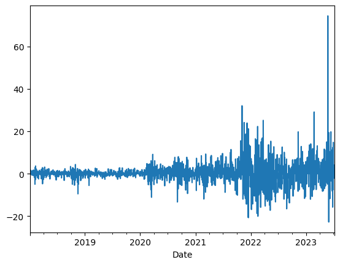

```python
data['Close_diff'] = data['Close'].diff()
data['Close_diff'].dropna().plot()
adf_test(data['Close_diff'].dropna())
```

```
Results of Dickey-Fuller Test:
Test Statistic                  -49.789671
p-value                           0.000000
#Lags Used                        0.000000
Number of Observations Used    2011.000000
Critical Value (1%)              -3.433606
Critical Value (5%)              -2.862978
Critical Value (10%)             -2.567536
dtype: float64
```

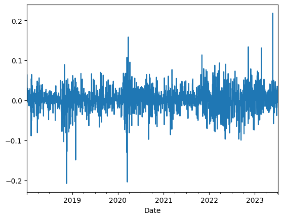

```python
data['Close_log'] = np.log(data['Close'])
data['Close_log_diff'] = data['Close_log'].diff()
data['Close_log_diff'].dropna().plot()
adf_test(data['Close_log_diff'].dropna())
```

```python
#from statsmodels.tsa.seasonal import seasonal_decompose
#decomposition = seasonal_decompose(data['Close'])

#trend = decomposition.trend
#seasonal = decomposition.seasonal
#residual = decomposition.resid

#residual.dropna().plot()
```

```python
train=data[(data.index<="2023-06-30")]
test=data[(data.index>"2023-06-30")]
```

```python
train.shape
```

```
(2006, 11)
```

```python
train
```

| Date | Open | High | Low | Close | Adj Close | Volume | year | is_quarter_end | Close_diff | Close_log | Close_log_diff |
| --- | --- | --- | --- | --- | --- | --- | --- | --- | --- | --- | --- |
| 2018-01-02 | 48.945000 | 49.875000 | 48.625000 | 49.837502 | 49.321198 | 35561600 | 2018 | 0 | NaN | 3.908768 | NaN |
| 2018-01-03 | 51.025002 | 53.424999 | 50.937500 | 53.117500 | 52.567207 | 91470400 | 2018 | 0 | 3.279999 | 3.972506 | 0.063739 |
| 2018-01-04 | 53.939999 | 54.512501 | 53.172501 | 53.397499 | 52.844315 | 58326800 | 2018 | 0 | 0.279999 | 3.977764 | 0.005257 |
| 2018-01-05 | 53.547501 | 54.227501 | 52.770000 | 53.849998 | 53.292110 | 58012400 | 2018 | 0 | 0.452499 | 3.986202 | 0.008438 |
| 2018-01-06 | 53.547501 | 54.227501 | 52.770000 | 53.849998 | 53.292110 | 58012400 | 2018 | 0 | 0.000000 | 3.986202 | 0.000000 |
| ... | ... | ... | ... | ... | ... | ... | ... | ... | ... | ... | ... |
| 2023-06-26 | 424.609985 | 427.640015 | 401.000000 | 406.320007 | 406.320007 | 59432200 | 2023 | 1 | -15.769989 | 6.007141 | -0.038078 |
| 2023-06-27 | 407.989990 | 419.399994 | 404.480011 | 418.760010 | 418.760010 | 46217500 | 2023 | 1 | 12.440002 | 6.037298 | 0.030157 |
| 2023-06-28 | 406.600006 | 418.450012 | 405.179993 | 411.170013 | 411.170013 | 58263900 | 2023 | 1 | -7.589996 | 6.019007 | -0.018291 |
| 2023-06-29 | 415.579987 | 416.000000 | 406.000000 | 408.220001 | 408.220001 | 38051400 | 2023 | 1 | -2.950012 | 6.011806 | -0.007201 |
| 2023-06-30 | 416.799988 | 425.500000 | 415.010010 | 423.019989 | 423.019989 | 50053400 | 2023 | 1 | 14.799988 | 6.047419 | 0.035613 |

2006 rows × 11 columns

```python
test.shape
```

```
(7, 11)
```

### AR (Autoregressive) Models:

The Autoregressive (AR) model uses the dependent relationship between an observation and some number of lagged observations (observations at prior points in time). For instance, an AR(1) model would predict the value at the present time based on the value at the previous time.

Benefits of AR Models:

1.They're simple to understand and implement.  
2.They're relatively efficient in terms of computational resources.

I got this error ""/usr/local/lib/python3.11/site-packages/statsmodels/tsa/base/tsa_model.py:473: ValueWarning: A date index has been provided, but it has no associated frequency information and so will be ignored when e.g. forecasting.self._init_dates(dates, freq)"" To overcome i set the freq of data as Daily

```python
data
```

| Date | Open | High | Low | Close | Adj Close | Volume | year | is_quarter_end | Close_diff | Close_log | Close_log_diff |
| --- | --- | --- | --- | --- | --- | --- | --- | --- | --- | --- | --- |
| 2018-01-02 | 48.945000 | 49.875000 | 48.625000 | 49.837502 | 49.321198 | 35561600 | 2018 | 0 | NaN | 3.908768 | NaN |
| 2018-01-03 | 51.025002 | 53.424999 | 50.937500 | 53.117500 | 52.567207 | 91470400 | 2018 | 0 | 3.279999 | 3.972506 | 0.063739 |
| 2018-01-04 | 53.939999 | 54.512501 | 53.172501 | 53.397499 | 52.844315 | 58326800 | 2018 | 0 | 0.279999 | 3.977764 | 0.005257 |
| 2018-01-05 | 53.547501 | 54.227501 | 52.770000 | 53.849998 | 53.292110 | 58012400 | 2018 | 0 | 0.452499 | 3.986202 | 0.008438 |
| 2018-01-06 | 53.547501 | 54.227501 | 52.770000 | 53.849998 | 53.292110 | 58012400 | 2018 | 0 | 0.000000 | 3.986202 | 0.000000 |
| ... | ... | ... | ... | ... | ... | ... | ... | ... | ... | ... | ... |
| 2023-07-03 | 425.170013 | 428.980011 | 422.019989 | 424.130005 | 424.130005 | 19820900 | 2023 | 0 | 1.110016 | 6.050040 | 0.002621 |
| 2023-07-04 | 425.170013 | 428.980011 | 422.019989 | 424.130005 | 424.130005 | 19820900 | 2023 | 0 | 0.000000 | 6.050040 | 0.000000 |
| 2023-07-05 | 421.350006 | 431.769989 | 420.850006 | 423.170013 | 423.170013 | 32361800 | 2023 | 0 | -0.959991 | 6.047774 | -0.002266 |
| 2023-07-06 | 418.440002 | 421.790009 | 413.459991 | 421.029999 | 421.029999 | 30358200 | 2023 | 0 | -2.140015 | 6.042704 | -0.005070 |
| 2023-07-07 | 423.220001 | 432.140015 | 421.799988 | 425.029999 | 425.029999 | 35525300 | 2023 | 0 | 4.000000 | 6.052160 | 0.009456 |

2013 rows × 11 columns

A step ahead if we want to optimize the lag :

# Choosing an optimal number of lags

is important for a good fit of the model to the data and selecting the optimal model order helps capture the underlying patterns in the data more accurately. There are different ways to look for it

#### Auto Correlation (ACF) and Partial autoCorrelation plots (PACF) plots :

The ACF measures the correlation between a time series and its lagged values while considering all intermediate lags. It provides a measure of the overall correlation at different lags, capturing both direct and indirect relationships. The ACF gives a broader view of the correlation structure in the time series.

The PACF, on the other hand, measures the correlation between a time series and its lagged values after removing the effects of intermediate lags. It focuses on the direct relationship between a time series and specific lagged values, excluding the influence of the other lags. The PACF provides more direct and isolated measures of correlation at each lag.

The key differences between ACF and PACF are as follows:

1. The ACF captures the overall correlation structure of a time series, including both direct and indirect relationships. The PACF focuses specifically on the direct correlation between the time series and lagged values after removing the influence of intermediate lags.
2. The ACF plot shows the autocorrelation values for various lags, allowing for an assessment of the decay of correlations over time. The PACF plot displays the partial autocorrelation values for different lags, highlighting the direct relationship between the time series and specific lagged values.
3. The ACF is often used to identify the order of a moving average (MA) model, while the PACF is primarily used to determine the order of an autoregressive (AR) model.

Sometimes, we observe overlapping spikes or multiple significant lags. Here we observe a series with significant positive autocorrelation at consecutive lags with a steady downward trend, while if we have significant autocorrelation at alternating lags will indicate a more cyclical or seasonal pattern. So indicates our data has trend In such cases, selecting the optimal lag may require a more nuanced evaluation, considering other model selection techniques like information criteria (AIC, BIC) or cross-validation.

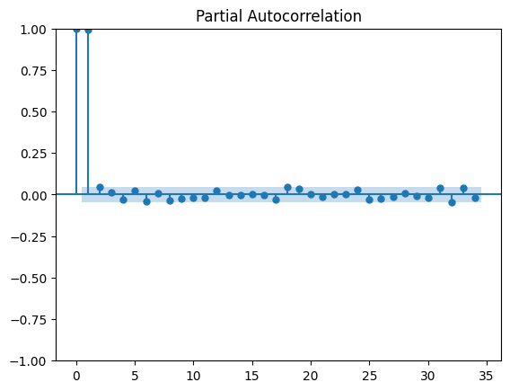

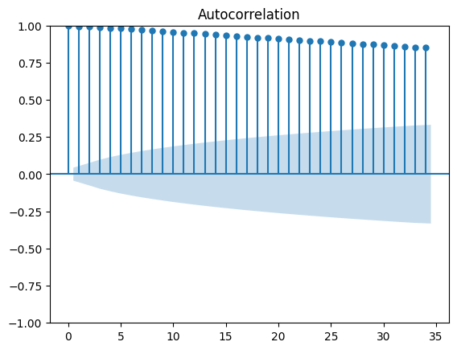

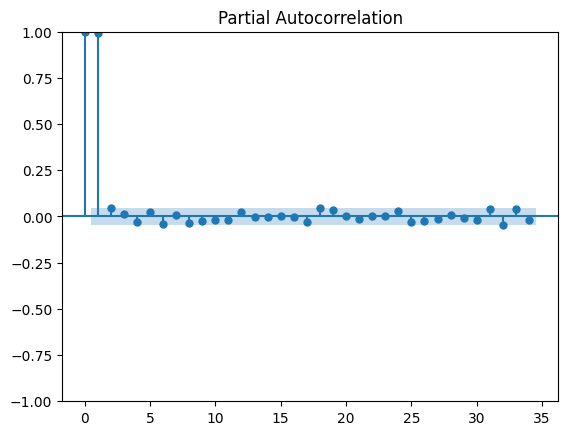

```python
#from statsmodels.graphics.tsaplots import plot_acf, plot_pacf
plot_acf(train['Close'])
plot_pacf(train['Close'])
```

Way to determine the number of lags is to fit the model with different numbers of lags and compare the goodness of fit using a criterion such as the Akaike Information Criterion (AIC) or the Bayesian Information Criterion (BIC). Basically these criteria will take into account both the goodness of fit of the model and the complexity of the model (in terms of the number of parameters), with a penalty for more complex models. ploting autocorrelation plot or partial auto correlation plot .

1. Akaike Information Criterion (AIC): The AIC is derived from information theory and is used for model selection. It balances the goodness of fit and the complexity of the model. The formula for AIC is: AIC = -2 *log-likelihood + 2* k,

where:

log-likelihood: The maximized log-likelihood of the model, which measures how well the model fits the data.

k: The number of parameters in the model, which represents the complexity or the number of estimated parameters.

The AIC penalizes models with more parameters, aiming to find a balance between model fit and parsimony. The goal is to select the model with the lowest AIC value, indicating a better trade-off between fit and complexity.

1. Bayesian Information Criterion (BIC): The BIC, also known as the Schwarz criterion, is based on Bayesian statistics. It is another criterion for model selection that considers the goodness of fit and model complexity. The formula for BIC is: BIC = -2 *log-likelihood + log(n)* k,

where:

n: The sample size, the number of observations in the dataset.

The BIC penalizes models more strongly for model complexity than the AIC, particularly for smaller sample sizes (as indicated by the term log(n) * k). Like the AIC, the goal is to select the model with the lowest BIC value.

Both AIC and BIC aim to strike a balance between model fit and complexity, but they apply different penalties for model complexity. The AIC is generally more lenient in penalizing complex models compared to the BIC. The appropriate criterion to use depends on the specific context and the desired balance between fit and complexity.

1. Hannan-Quinn Information Criterion (HQIC): is another criterion used for model selection and comparison. It shares similarities with AIC and BIC but incorporates an additional penalty term for model complexity.

The formula for HQIC is as follows:

HQIC = -2 *log-likelihood + 2* k * log(log(n)),

where:

Similar to AIC and BIC, the goal is to select the model with the lowest HQIC value. HQIC provides a trade-off between model fit and complexity, considering the sample size in the penalty term.

Compared to AIC, HQIC applies a stronger penalty for model complexity, while BIC imposes a stronger penalty than both AIC and HQIC. The appropriate criterion to use depends on the specific context and the desired balance between fit and complexity.

Including HQIC alongside AIC and BIC in model selection allows for a more comprehensive evaluation, considering different perspectives on model fit and complexity.

```python
best_aic = np.inf
best_lag = None
best_model = None
for lag in range(40,50):
    df_ar = train['Close_diff'].dropna()
    model = AutoReg(df_ar, lags=lag, old_names=False)
    model_fit = model.fit()
    print(lag, model_fit.aic)
    if model_fit.aic < best_aic:
        best_aic = model_fit.aic
        best_lag = lag
        best_model = model_fit

print('Best AIC: ', best_aic)
print('Best lag order: ', best_lag)
```

```
40 11548.253320443684
41 11545.208327455199
42 11537.680825164794
43 11533.38364670015
44 11529.400997014
45 11526.446654939009
46 11522.7594339354
47 11513.816015434217
48 11510.26125546955
49 11504.509479972528
Best AIC:  11504.509479972528
Best lag order:  49
```

As AIC values for an AR model show a decreasing trend as the lag order increases, it suggests that the model is becoming more complex but not necessarily improving in terms of goodness of fit. In such cases, it is essential to consider alternative approaches to select an appropriate lag order for your AR model.

1. Evaluating higher order lags by investigate the ACF and PACF plots. If there are any significant autocorrelations or partial autocorrelations at specific lags. These plots may provide guidance on selecting a reasonable upper limit for the lag order.
2. Examine the residuals of the AR models fitted with different lag orders. Look for patterns or systematic behaviors in the residuals. If the residuals exhibit significant autocorrelation or other undesirable characteristics, it suggests that the selected lag order is not adequately capturing the underlying dynamics. In such cases, it may be necessary to reconsider the lag order selection.
3. Use cross-validation techniques to evaluate the out-of-sample performance of different lag orders. Split your data into training and testing sets, fit AR models with various lag orders on the training data, and evaluate their performance on the testing data. Select the lag order that produces the best forecasting accuracy or model performance on unseen data.

As decreasing trend in AIC values persists across various lag orders, it may indicate that an AR model is not the most appropriate choice for your data. we should explore alternative models such as moving averages (MA), autoregressive moving average (ARMA), autoregressive integrated moving average (ARIMA), or other time series models that can capture more complex dynamics or account for other factors affecting your data.

```python
#def autoreg(start_date,end_date, num_periods,):
from statsmodels.tsa.ar_model import AutoReg
df_ar = train['Close_diff'].dropna()
model_ar = AutoReg(df_ar, lags=50)
model_ar_fit = model_ar.fit()
print(model_ar_fit.aic, model_ar_fit.hqic, model_ar_fit.bic)
predictions_ar = model_ar_fit.predict(start='2023-01-03', end='2023-06-30', dynamic=False)
n_periods = 7
forecast = model_ar_fit.forecast(steps=n_periods)
# The forecast variable is an array of the forecasted values
print('Forecast: ', forecast)
```

```
11499.571347834448 11606.199272779735 11789.63491240026
Forecast:  2023-07-01   -1.025826
2023-07-02    4.507141
2023-07-03   -0.846023
2023-07-04    4.563347
2023-07-05   -0.695414
2023-07-06   -5.587194
2023-07-07    4.351654
Freq: D, dtype: float64
```

```python
forecast_undiff = np.r_[train['Close'][-1], forecast].cumsum()
df_forecast = pd.DataFrame({'Close': forecast_undiff[1:]}, index=pd.date_range(start=test.index[0], periods=n_periods, freq='D'))
```

```python
train['Close'][-1]
```

```
423.0199890136719
```

```python
df_forecast
```

[output not shown]

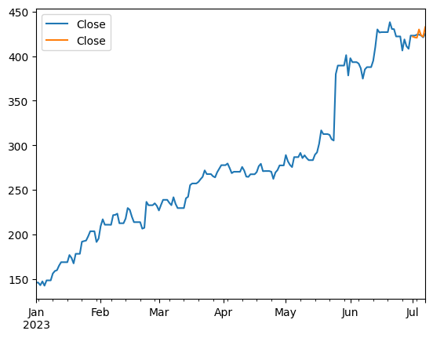

```python
df1_filtered = data[data.index >= '2023-01-01']
pd.concat([df1_filtered['Close'],df_forecast],axis=1).plot()
```

## ARIMA : Autoregressive Integrated Moving Average

ARIMA models are widely used for modeling and forecasting time series data. They capture the linear dependencies between past observations and use differencing to handle non-stationarity. ARIMA models are effective for capturing short-term patterns and can be tuned with parameters such as autoregressive (p), differencing (d), and moving average (q) components.

### Some question/Challenges

[output not shown]

[figure not shown]

```python
# CandlePlot for Sep2019 to Dec 2019
fig,ax = plt.subplots(figsize=(8,4))
def candlestick(df,ax):
    ax.vlines(x=df.index, ymin=df.Low, ymax=df.High, color='r', linewidth=1)
    red = df.query('Open > Close')
    ax.vlines(x=red.index,ymin=red.Close, ymax=red.Open, color='r', linewidth=3)
    green = df.query('Open <= Close')
    ax.vlines(x=green.index,ymin=green.Open, ymax=green.Close, color='g', linewidth=3)
    ax.xaxis.set_major_locator(dates.MonthLocator())
    ax.xaxis.set_major_formatter(dates.DateFormatter('%b-%y'))
    ax.xaxis.set_minor_locator(dates.DayLocator())
    return df
(data
 .iloc[:,::2]
 .pipe(fix_col)
 .resample('d')
 .agg({'Close':'last', 'Open':'first',  'High':'max', 'Low':'min'})
 .loc['Sep 2019':'Dec 2019']
 .pipe(candlestick,ax)
)
```

```python
#Returns

app = (data
       .iloc[:,::2]
       .pipe(fix_col)
      )

app
```

[output not shown]

```python
app.diff()
```

[output not shown]

3392 rows × 6 columns

```python
# percentage change r2-r1/r2
app.pct_change()
```

| Date | Adj Close | Close | High | Low | Open | Volume |
| --- | --- | --- | --- | --- | --- | --- |
| 2010-01-04 | NaN | NaN | NaN | NaN | NaN | NaN |
| 2010-01-05 | 0.001729 | 0.001729 | 0.005082 | 0.004096 | 0.005482 | 0.219098 |
| 2010-01-06 | -0.015906 | -0.015906 | -0.001670 | -0.011723 | -0.001025 | -0.082646 |
| 2010-01-07 | -0.001849 | -0.001849 | -0.015007 | -0.008066 | -0.012268 | -0.135882 |
| 2010-01-08 | 0.006648 | 0.006648 | 0.000000 | 0.000048 | -0.006848 | -0.061871 |
| ... | ... | ... | ... | ... | ... | ... |
| 2023-06-20 | 0.000487 | 0.000487 | -0.004760 | 0.000760 | -0.012424 | -0.508087 |
| 2023-06-21 | -0.005675 | -0.005675 | -0.003708 | -0.009869 | 0.002657 | -0.005691 |
| 2023-06-22 | 0.016525 | 0.016525 | 0.008845 | 0.005915 | -0.006274 | 0.034930 |
| 2023-06-23 | -0.001711 | -0.001711 | 0.002727 | 0.007296 | 0.009851 | 0.035789 |
| 2023-06-26 | -0.007553 | -0.007553 | 0.002613 | 0.001189 | 0.006898 | -0.094022 |

3392 rows × 6 columns

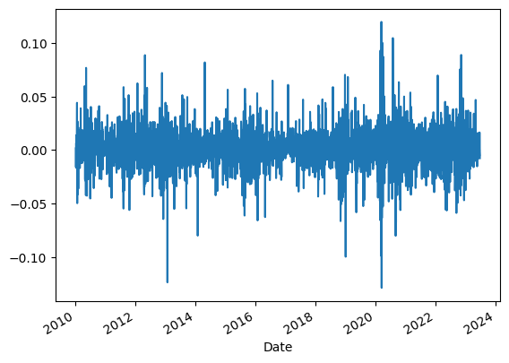

```python
# Plotting return
(app
 .pct_change()
 .Close
 .plot()
)
```

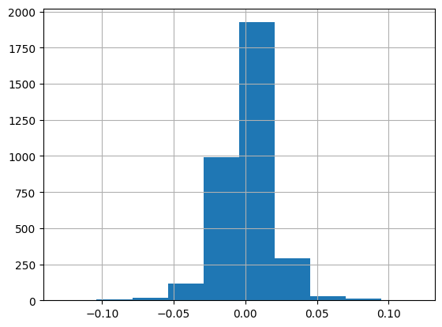

```python
(app
 .pct_change()
 .Close
 .hist()
)
```

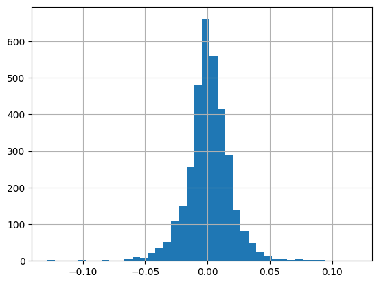

```python
(app
 .pct_change()
 .Close
 .hist(bins=40)
)
```

#

### Bar plot

Bar plots are commonly used in finance to visualize various aspects of financial data, such as comparing different assets, showing performance metrics, or displaying market trends. Here we can plot the bar plot lets plot it for last 50 values and basically index is going to go into the X-axis and then each value will be a bar at that point.

In pandas for bar plot it convert each value to categorial and thats why its show all zhe labels to fix it

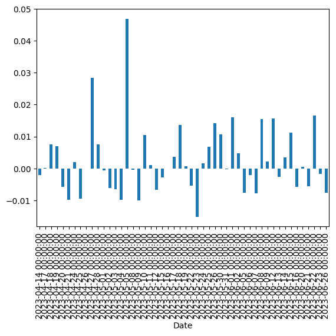

```python
(app
 .pct_change()
 .Close
 .iloc[-50:]
 .plot.bar()
)
```

```
Date
2023-02-01    0.007901
2023-02-02    0.037063
2023-02-03    0.024400
2023-02-06   -0.017929
2023-02-07    0.019245
                ...
2023-06-20    0.000487
2023-06-21   -0.005675
2023-06-22    0.016525
2023-06-23   -0.001711
2023-06-26   -0.007553
Name: Close, Length: 100, dtype: float64
```

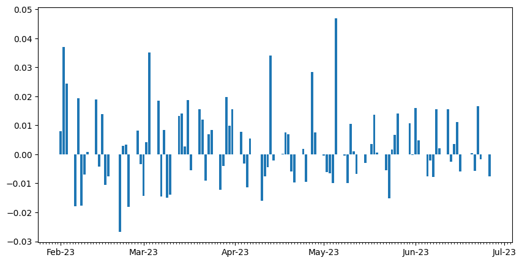

```python
def my_bar(ser,ax):
    ax.bar(ser.index,ser)
    ax.xaxis.set_major_locator(dates.MonthLocator())
    ax.xaxis.set_major_formatter(dates.DateFormatter('%b-%y'))
    ax.xaxis.set_minor_locator(dates.DayLocator())
    return ser

fig,ax = plt.subplots(figsize=(10,5))
(app
 .pct_change()
 .Close
 .iloc[-100:]   #max ticks is 1000
 .pipe(my_bar,ax)
)
```

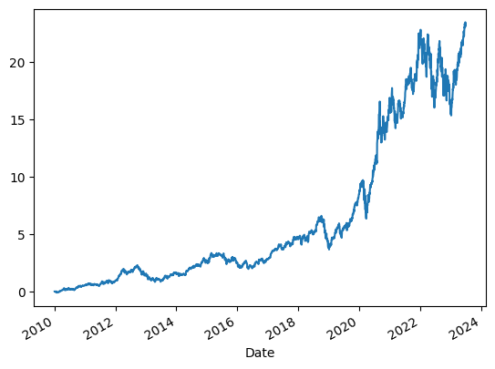

```python
#Cummulative return : Cumulative Return = (Final Value / Initial Value) - 1
# By Cumulative Return nvestors can assess the overall performance and growth of their investments over time,
#enabling them to make informed decisions about their portfolios.
(app
 .Close
 .sub(app.Close[0])
 .div(app.Close[0])
 .plot()
)
```

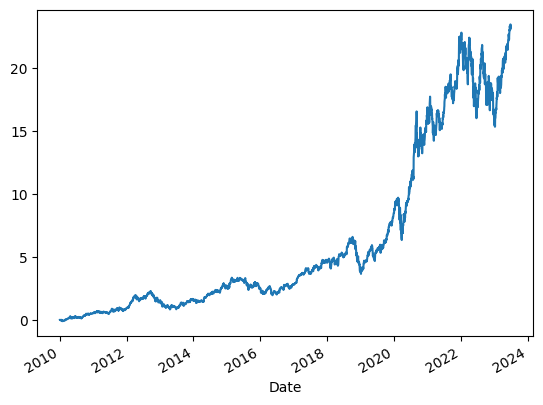

```python
#Inn fun

def com_return(df,col):
    ser= df[col]
    return(ser.sub(ser[0]).div(ser[0]))

(app
 .pipe(com_return,'Close')
 .plot()
)
```

```python
## if we need to add a new column can be dome qith a help of assign and lambda funda
app.assign(com_returns=lambda df:com_return(df,'Close'))
```

| Date | Adj Close | Close | High | Low | Open | Volume | com_returns |
| --- | --- | --- | --- | --- | --- | --- | --- |
| 2010-01-04 | 6.496294 | 7.643214 | 7.660714 | 7.585000 | 7.622500 | 493729600 | 0.000000 |
| 2010-01-05 | 6.507525 | 7.656429 | 7.699643 | 7.616071 | 7.664286 | 601904800 | 0.001729 |
| 2010-01-06 | 6.404015 | 7.534643 | 7.686786 | 7.526786 | 7.656429 | 552160000 | -0.014205 |
| 2010-01-07 | 6.392176 | 7.520714 | 7.571429 | 7.466071 | 7.562500 | 477131200 | -0.016027 |
| 2010-01-08 | 6.434673 | 7.570714 | 7.571429 | 7.466429 | 7.510714 | 447610800 | -0.009486 |
| ... | ... | ... | ... | ... | ... | ... | ... |
| 2023-06-20 | 185.009995 | 185.009995 | 186.100006 | 184.410004 | 184.410004 | 49799100 | 23.205784 |
| 2023-06-21 | 183.960007 | 183.960007 | 185.410004 | 182.589996 | 184.899994 | 49515700 | 23.068409 |
| 2023-06-22 | 187.000000 | 187.000000 | 187.050003 | 183.669998 | 183.740005 | 51245300 | 23.466147 |
| 2023-06-23 | 186.679993 | 186.679993 | 187.559998 | 185.009995 | 185.550003 | 53079300 | 23.424278 |
| 2023-06-26 | 185.270004 | 185.270004 | 188.050003 | 185.229996 | 186.830002 | 48088700 | 23.239803 |

3392 rows × 7 columns

```
Date
2023-04-28    21.200083
2023-05-01    21.188309
2023-05-02    21.050931
2023-05-03    20.908322
2023-05-04    20.691135
2023-05-05    21.709033
2023-05-08    21.699874
2023-05-09    21.473530
2023-05-10    21.707724
2023-05-11    21.732583
2023-05-12    21.578198
2023-05-15    21.512781
2023-05-16    21.512781
2023-05-17    21.593898
2023-05-18    21.902669
2023-05-19    21.917061
2023-05-22    21.791458
2023-05-23    21.446054
2023-05-24    21.482687
2023-05-25    21.633149
2023-05-26    21.952385
2023-05-30    22.197047
2023-05-31    22.190505
2023-06-01    22.562076
2023-06-02    22.674594
2023-06-05    22.495351
2023-06-06    22.446943
2023-06-07    22.265082
2023-06-08    22.624878
2023-06-09    22.675904
2023-06-12    23.046165
2023-06-13    22.983365
2023-06-14    23.067099
2023-06-15    23.336619
2023-06-16    23.194010
2023-06-20    23.205784
2023-06-21    23.068409
2023-06-22    23.466147
2023-06-23    23.424278
2023-06-26    23.239803
Name: Close, dtype: float64
```

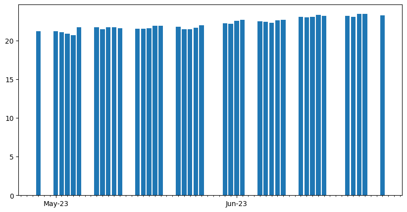

```python
## bar plot ffor cummulative return
def my_bar(ser,ax):
    ax.bar(ser.index,ser)
    ax.xaxis.set_major_locator(dates.MonthLocator())
    ax.xaxis.set_major_formatter(dates.DateFormatter('%b-%y'))
    ax.xaxis.set_minor_locator(dates.DayLocator())
    return ser

fig,ax = plt.subplots(figsize=(10,5))
(app
 #.resample('Q')
 #.mean()
 .pipe(com_return,'Close')
 .iloc[-40:]  #max ticks is 1000
 .pipe(my_bar,ax)
)
```

### Volality

volatility refers to the degree of variation or fluctuation in the price or value of a financial instrument, such as stocks, bonds, or commodities, over a specific period. It is a measure of the uncertainty or risk associated with an investment.

Volatility is commonly used to assess the potential price movements and riskiness of an asset. Higher volatility indicates larger price swings and greater uncertainty, while lower volatility suggests more stable and predictable price movements.

There are different methods to measure volatility, but two commonly used measures are:

Standard Deviation: The standard deviation is a statistical measure that quantifies the dispersion of a dataset from its mean. In finance, it is often used to calculate historical volatility. By analyzing the historical price data, the standard deviation provides an estimate of how much the prices have deviated from the average in the past. Higher standard deviation indicates higher volatility.

Volatility Index (VIX): The VIX is a popular index that measures the implied volatility of the options market. It reflects the market's expectations of future volatility. The VIX is often referred to as the "fear index" as it tends to rise during times of market stress and uncertainty. Volatility plays a crucial role in various aspects of finance, such as risk management, option pricing, portfolio construction, and trading strategies. It helps investors and traders assess the potential risks and rewards associated with different investments and make informed decisions.

It's important to note that volatility is not the same as the direction of price movements. A highly volatile asset can have significant price swings in both positive and negative directions, while a less volatile asset may have relatively smaller and more predictable price movements.

By understanding and analyzing volatility, market participants can better evaluate the potential risks and returns of their investments and adapt their strategies accordingly.

```python
(app
.Close
.mean())
```

```
55.16324859716982
```

```python
(app
.Close
.std())
```

```
50.73869814580789
```

```python
(app
.assign(pct_change_ = app.Close.pct_change())
.pct_change_
.std()
)
```

```
0.017961402006385203
```

### Rolling

Concept of "rolling" refers to a technique of calculating metrics or performing calculations repeatedly on a moving or rolling window of data. Rolling calculations are commonly used to analyze time-series data, such as stock prices, economic indicators, or financial ratios, in order to observe trends or patterns over a specified period.

The rolling window typically consists of a fixed number of consecutive observations or a defined time period. As new data becomes available, the window moves forward in time, and the calculations are updated using the latest observations while dropping the oldest ones.

With rolling we can have rolling mean ( Moving averages), Rolling standard deviation (Volality), rolling sum, rolling corelations

```
array([<Axes: xlabel='Date'>, <Axes: xlabel='Date'>], dtype=object)
```

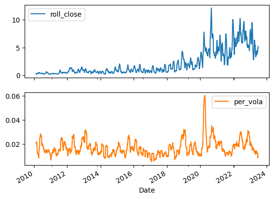

```python
(app
.assign(roll_close=app.rolling(30).Close.std(),
    per_vola = app.Close.pct_change().rolling(30).std())
 .iloc[:, -2:]
.plot(subplots=True)
)
```

```python
# 30 day volality from year 2015 to 2019
```

```
array([<Axes: xlabel='Date'>], dtype=object)
```

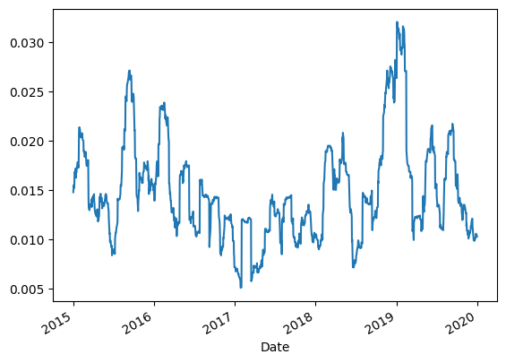

```python
(app
.assign(roll_close=app.rolling(30).Close.std(),
    per_vola = app.Close.pct_change().rolling(30).std())
 .loc['2015':'2019']
 .per_vola
.plot(subplots=True)
)
```

### Moving averages

we are calucalting moving average by 2 ways intutive ( by shifft) and built in

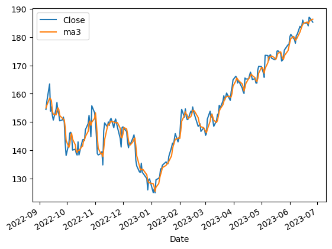

```python
(app
 .assign(s1=app.Close.shift(1),
         s2=app.Close.shift(2),
         ma3=lambda df_:df_.loc[:,['Close','s1','s2']].mean(axis='columns'),
         ma3_builtin = app.Close.rolling(3).mean()
         )
 [['Close','ma3']]
 .iloc[-200:,:]

 .plot()

)
```

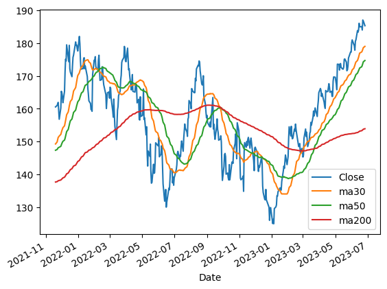

```python
# Comparison between 50 day moving average to 200 day

(app
 .assign(ma30 = app.Close.rolling(30).mean(),
         ma50 = app.Close.rolling(50).mean(),
         ma200 = app.Close.rolling(200).mean()
        )
 [['Close','ma30','ma50','ma200']]
 .iloc[-400:,]
 .plot()



)
```

### here just we want to comapre

```
- appl lose price in 2015
- exponential moving average with alpha =0.392 and alpha =0.00995
```

The exponential moving average (EMA) is a technical chart indicator that tracks the price over time. The EMA is a type of weighted moving average (WMA) that gives more weighting or importance to recent price data.

```python
app.ewm??
```

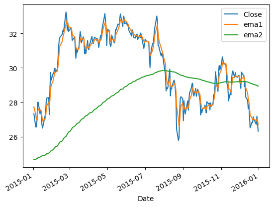

```python
(app
.assign(ema1=app.Close.ewm(alpha=0.392).mean(),
        ema2=app.Close.ewm(alpha=0.00995).mean()
       )
 [['Close','ema1','ema2']]
 .loc['2015']
 .plot()
)
```

### Techinical analysis

On-Balance Volume (OBV): is a technical analysis indicator used in finance to measure the cumulative buying and selling pressure of a security over a specified period. It is based on the theory that changes in volume can precede price movements. OBV is calculated by adding the volume of an asset to a running total if the price of the asset closes higher than the previous day's closing price. If the price closes lower than the previous day's closing price, the volume is subtracted from the running total. If the price remains unchanged, the volume is not added or subtracted. The resulting OBV line can help identify trends and potential reversals in the price of the security. On-balance Volume (OBV)

```
OBV: On-balance Volume level
OBV_{Previous}: Previous On-balance Volume level
volume: Last trending volume amount
```

```python
app.Close
```

```
Date
2010-01-04      7.643214
2010-01-05      7.656429
2010-01-06      7.534643
2010-01-07      7.520714
2010-01-08      7.570714
                 ...
2023-06-20    185.009995
2023-06-21    183.960007
2023-06-22    187.000000
2023-06-23    186.679993
2023-06-26    185.270004
Name: Close, Length: 3392, dtype: float64
```

```python
app.Close.shift(1)
```

```
Date
2010-01-04           NaN
2010-01-05      7.643214
2010-01-06      7.656429
2010-01-07      7.534643
2010-01-08      7.520714
                 ...
2023-06-20    184.919998
2023-06-21    185.009995
2023-06-22    183.960007
2023-06-23    187.000000
2023-06-26    186.679993
Name: Close, Length: 3392, dtype: float64
```

```python
%%timeit
def cal_obv(df):
    df = df.copy()
    df['OBV'] = 0.0
    for i in range(len(df)):
        if df['Close'][i] > df['Close'][i-1]:
            df['OBV'][i] = df['OBV'][i-1]+ df['Volume'][i]
        if df['Close'][i] < df['Close'][i-1]:
            df['OBV'][i] = df['OBV'][i-1]- df['Volume'][i]
        if df['Close'][i] == df['Close'][i-1]:
            df['OBV'][i] = df['OBV'][i-1]
    return df

## Loop

#cal_obv(app)
```

```
123 ns ± 20.8 ns per loop (mean ± std. dev. of 7 runs, 10,000,000 loops each)
```

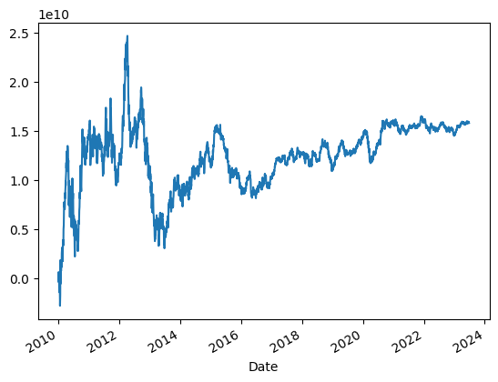

```python
#%%timeit
## morepanda way
(app
 .assign(close_prev = app.Close.shift(1),
         vol=0,
         obv=lambda adf: adf.vol.where(cond=adf.Close== adf.close_prev,
                          other=adf.Volume.where(cond=adf.Close>adf.close_prev,
                          other=-adf.Volume.where(cond=adf.Close<adf.close_prev,other=0)
                          )).cumsum()

        )
 ['obv']
  .plot()
)
```

```python
#select funtion of numpy is good for conditions if else

var= pd.Series(np.select(condlist=[app.Close<7.6, app.Close > 7.6],choicelist=[7.55,22],default=33))
var
```

```
0       22.00
1       22.00
2        7.55
3        7.55
4        7.55
        ...
3387    22.00
3388    22.00
3389    22.00
3390    22.00
3391    22.00
Length: 3392, dtype: float64
```

```
array([<Axes: xlabel='Date'>, <Axes: xlabel='Date'>], dtype=object)
```

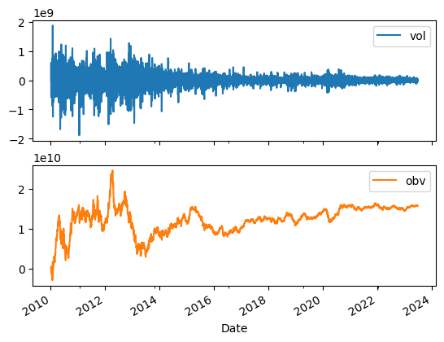

```python
(app
.assign(vol=np.select([app.Close == app.Close.shift(1),
                      app.Close > app.Close.shift(1),
                      app.Close < app.Close.shift(1),],
                      [0,app.Volume,-app.Volume]),
            obv = lambda _df : _df.vol.cumsum()
       )
 [['vol','obv']]
 .plot(subplots=True)


)
```

### Acumulation/ Distribution Indicator (A/D) :

The Accumulation/Distribution Indicator (A/D) is a technical analysis tool used to assess the flow of money into or out of a security. It is based on the premise that the volume of trading activity is an important factor in determining the strength and direction of a price trend.

The A/D indicator calculates a cumulative value by considering both the price and volume data. It is typically used to confirm the strength of a trend and identify potential reversals.

The formula for calculating the Accumulation/Distribution Indicator (A/D) is as follows:

A/D = Previous A/D + CMFV where CMFV is current money flow Volume

MFV= MFM * Volume ,MFV is money flow Volume

MFM =[(Close - Low) - (High - Close)] / (High - Low) ,MFM is Money Flow Multiplier

Where:

Previous A/D: The value of the A/D indicator from the previous period. Close: The closing price of the current period. Low: The lowest price of the current period. High: The highest price of the current period. Volume: The volume of trading activity during the current period.

The A/D indicator takes into account whether the closing price is closer to the high or low of the period, as well as the volume traded. If the closing price is closer to the high, it suggests buying pressure, while if it is closer to the low, it suggests selling pressure. The A/D line can be plotted on a chart along with the price of the security. When the A/D line is moving in the same direction as the price, it confirms the strength of the trend. Divergence between the A/D line and the price can indicate potential trend reversals.

Traders and analysts use the A/D indicator to gauge the demand and supply dynamics of a security and make informed decisions about buying or selling. It can help identify potential buying or selling opportunities and confirm the sustainability of a price trend.

```python
(app
 .assign(mfm= ((app.Close-app.Low) -(app.High-app.Close))/(app.High-app.Low),
         mfv= lambda _df : _df.mfm*_df.Volume,
         cmfv= lambda  _df :_df.mfv.cumsum()
 )
 #[['cmfv','mfv']]
 #.plot()



)
```

| Date | Adj Close | Close | High | Low | Open | Volume | mfm | mfv | cmfv |
| --- | --- | --- | --- | --- | --- | --- | --- | --- | --- |
| 2010-01-04 | 6.496294 | 7.643214 | 7.660714 | 7.585000 | 7.622500 | 493729600 | 0.537737 | 2.654966e+08 | 2.654966e+08 |
| 2010-01-05 | 6.507525 | 7.656429 | 7.699643 | 7.616071 | 7.664286 | 601904800 | -0.034183 | -2.057486e+07 | 2.449217e+08 |
| 2010-01-06 | 6.404015 | 7.534643 | 7.686786 | 7.526786 | 7.656429 | 552160000 | -0.901784 | -4.979289e+08 | -2.530072e+08 |
| 2010-01-07 | 6.392176 | 7.520714 | 7.571429 | 7.466071 | 7.562500 | 477131200 | 0.037280 | 1.778734e+07 | -2.352198e+08 |
| 2010-01-08 | 6.434673 | 7.570714 | 7.571429 | 7.466429 | 7.510714 | 447610800 | 0.986385 | 4.415166e+08 | 2.062968e+08 |
| ... | ... | ... | ... | ... | ... | ... | ... | ... | ... |
| 2023-06-20 | 185.009995 | 185.009995 | 186.100006 | 184.410004 | 184.410004 | 49799100 | -0.289953 | -1.443938e+07 | 2.800024e+10 |
| 2023-06-21 | 183.960007 | 183.960007 | 185.410004 | 182.589996 | 184.899994 | 49515700 | -0.028364 | -1.404461e+06 | 2.799884e+10 |
| 2023-06-22 | 187.000000 | 187.000000 | 187.050003 | 183.669998 | 183.740005 | 51245300 | 0.970412 | 4.972908e+07 | 2.804856e+10 |
| 2023-06-23 | 186.679993 | 186.679993 | 187.559998 | 185.009995 | 185.550003 | 53079300 | 0.309801 | 1.644402e+07 | 2.806501e+10 |
| 2023-06-26 | 185.270004 | 185.270004 | 188.050003 | 185.229996 | 186.830002 | 48088700 | -0.971625 | -4.672419e+07 | 2.801828e+10 |

3392 rows × 9 columns

```python
def cal_sd(df):
    close = df.Close
    low  = df.Low
    high = df.High
    volume = df.Volume
    ad = df.assign(mfm=((close-low)-(high-close))/(high-low),
                   mfv = lambda  _df : _df.mfm *volume,
                   cmfv = lambda _df : _df.mfv.cumsum()
                  )
    return ad

(
app
.pipe(cal_sd)

)
```

| Date | Adj Close | Close | High | Low | Open | Volume | mfm | mfv | cmfv |
| --- | --- | --- | --- | --- | --- | --- | --- | --- | --- |
| 2010-01-04 | 6.496294 | 7.643214 | 7.660714 | 7.585000 | 7.622500 | 493729600 | 0.537737 | 2.654966e+08 | 2.654966e+08 |
| 2010-01-05 | 6.507525 | 7.656429 | 7.699643 | 7.616071 | 7.664286 | 601904800 | -0.034183 | -2.057486e+07 | 2.449217e+08 |
| 2010-01-06 | 6.404015 | 7.534643 | 7.686786 | 7.526786 | 7.656429 | 552160000 | -0.901784 | -4.979289e+08 | -2.530072e+08 |
| 2010-01-07 | 6.392176 | 7.520714 | 7.571429 | 7.466071 | 7.562500 | 477131200 | 0.037280 | 1.778734e+07 | -2.352198e+08 |
| 2010-01-08 | 6.434673 | 7.570714 | 7.571429 | 7.466429 | 7.510714 | 447610800 | 0.986385 | 4.415166e+08 | 2.062968e+08 |
| ... | ... | ... | ... | ... | ... | ... | ... | ... | ... |
| 2023-06-20 | 185.009995 | 185.009995 | 186.100006 | 184.410004 | 184.410004 | 49799100 | -0.289953 | -1.443938e+07 | 2.800024e+10 |
| 2023-06-21 | 183.960007 | 183.960007 | 185.410004 | 182.589996 | 184.899994 | 49515700 | -0.028364 | -1.404461e+06 | 2.799884e+10 |
| 2023-06-22 | 187.000000 | 187.000000 | 187.050003 | 183.669998 | 183.740005 | 51245300 | 0.970412 | 4.972908e+07 | 2.804856e+10 |
| 2023-06-23 | 186.679993 | 186.679993 | 187.559998 | 185.009995 | 185.550003 | 53079300 | 0.309801 | 1.644402e+07 | 2.806501e+10 |
| 2023-06-26 | 185.270004 | 185.270004 | 188.050003 | 185.229996 | 186.830002 | 48088700 | -0.971625 | -4.672419e+07 | 2.801828e+10 |

3392 rows × 9 columns

### Relative strength Index

The Relative Strength Index (RSI) is a popular technical analysis indicator used to measure the speed and change of price movements in a security. It helps traders and analysts identify overbought and oversold conditions, potential trend reversals, and the overall strength of a price trend.

The RSI is calculated based on the average gains and losses over a specified period, typically 14 days. The formula for calculating the RSI is as follows:

RSI = 100 - (100 / (1 + RS))

Where:

RS (Relative Strength) = Average Gain / Average Loss

Average Gain = Average of the gains over the specified period Average Loss = Average of the losses over the specified period

The RSI value ranges from 0 to 100. Traditionally, an RSI value above 70 is considered overbought, indicating a potential price reversal or correction to the downside. Conversely, an RSI value below 30 is considered oversold, suggesting a potential price reversal or bounce to the upside. These threshold values can be adjusted based on the specific security or trading strategy.

The RSI is typically displayed as a line chart with values ranging from 0 to 100. Traders often look for bullish or bearish divergences between the RSI and the price, where the RSI moves in the opposite direction to the price, signaling a potential change in trend.

It's important to note that the RSI is just one tool among many used in technical analysis, and it should be used in conjunction with other indicators and analysis techniques to make well-informed trading decisions. The RSI is most effective when combined with other indicators or used in conjunction with support and resistance levels, trendlines, or other chart patterns.